# 05 Plots

## Now for some fun

There is more to be said about data wrangling, and we will get back to it, but I want to create some plots first. Plots are fun because they give you nice and colourful results, and they are a very important tool for inspecting your data and getting an intuition for it. While base `R` has a plotting function, the `tidyverse`’s `ggplot2` is what is partly responsible for `R`’s fame.

`ggplot2` is based on the [“Grammar of Graphics” by Leland Wilkinson](https://www.springer.com/de/book/9780387245447), a framework for good data visualisation in data science. In a way, `ggplot2` has a grammar of its own, which is something new for us. But don’t worry, it all makes sense.

## Call other scripts

First, we need some data. If the data from previous exercises is still in your environment, use this opportunity to clear your workspace using `rm(list = ls())`. We want to start with a clean slate. However, the work we did in the previous data wrangling script should not go to waste. We don’t need to run all our code in the same script - in fact, it’s good practice to distribute your code across several scripts so you know where to find what. The preprocessing could e.g. go into one script, the analysis into another one and then you could have a separate script for plots or tables. Here, we want to run the preprocessing we did in the data wrangling script (excluding participants with implausible values etc.) and then work with the clean data in this script. However, we don’t want to run the whole file with all exercises in it - we only need the relevant preprocessing steps. Also, we don’t want to render the whole R Markdown file - we just want the preprocessing to run in the background. I put the relevant preprocessing steps into a script called “nerd_preprocessing.R”. You can find it in the same folder as this R Markdown file. Take a moment to look at the individual steps in the preprocessing file before you continue.

We call our preprocessing script using the function `source()`. It runs the file that you named in the first argument (don’t forget the file extension “.R”). Open your environment tab in the top right corner of RStudio and then run the following code cell. In your empty environment, the variables `nerd` and `nerd_red` should appear.

```r
library(tidyverse)
source("nerd_preprocessing.R")
```

## Simple plots

One basic plot that you will frequently need is a histogram. It’s a good way to quickly inspect the distribution of your data. Below, you see how a simple histogram for the participant age works. The concept is pretty simple: We pipe our data, `nerd_red` into the `ggplot()` function. Within the function, we use the `aes()` function, which stands for “aesthetics”. The aesthetic function is used to tell `ggplot()` all the information that is related to the data (as opposed to things that have nothing to do with the data, e.g. overall plot colour). It will make more sense once we see which things belong into `aes()` and which things belong outside of it. Unsurprisingly, the argument `x` is what we want to put on the x-axis, which is the age of our participants in this case. Lastly, we tell `ggplot()` to make a histogram from our data. Ggplot uses different “geoms”, which you can imagine as different “geometric” plot shapes. Other geoms are for example `geom_point`, `geom_bar` or `geom_boxplot`. You can probably guess what they do. The special thing is that we don’t use a pipe to add the histogram, but a plus sign. That is because `ggplot()` works with “layers”. It’s a bit like using PowerPoint: When you created a slide, some elements are behind/in front of each other. In `ggplot2`, it’s the same principle. Here, we already use two layers: The plot background as first layer, and then there’s our histogram on top of that.

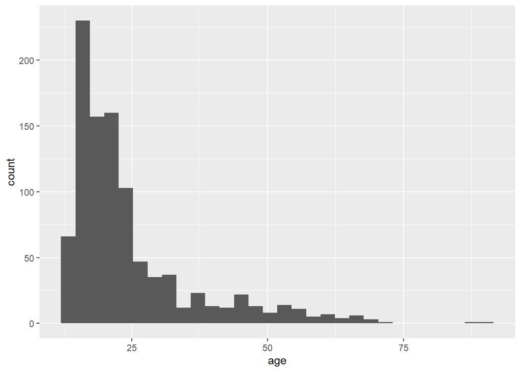

```r
nerd_red %>%
  ggplot(aes(x = age)) +
  geom_histogram(bins = 30)
```

We can observe the layered structure by leaving out the histogram layer. Here, we can see that `ggplot()` still drew the plot background for us. It also labelled the x-axis with “age”, because it knows that our age data will go there. Furthermore, it picked a sensible scale for the axis, because it knows the minimum/maximum of our data and can figure out the range it will need to plot. However, no data is plotted, and there is no y-axis, because did not provide any information for the y-axis. In our previous plot, `geom_histogram` automatically counted how many participants were in each age bin, and based the y-axis on that.

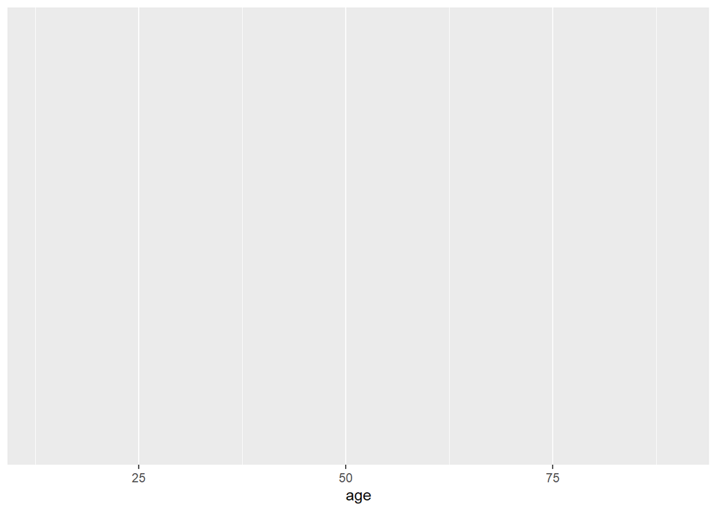

```r
nerd_red %>%
  ggplot(aes(x = age))
```

Let’s check out a different geom. Try `geom_boxplot()`. It looks a bit weird - what might be the problem here?

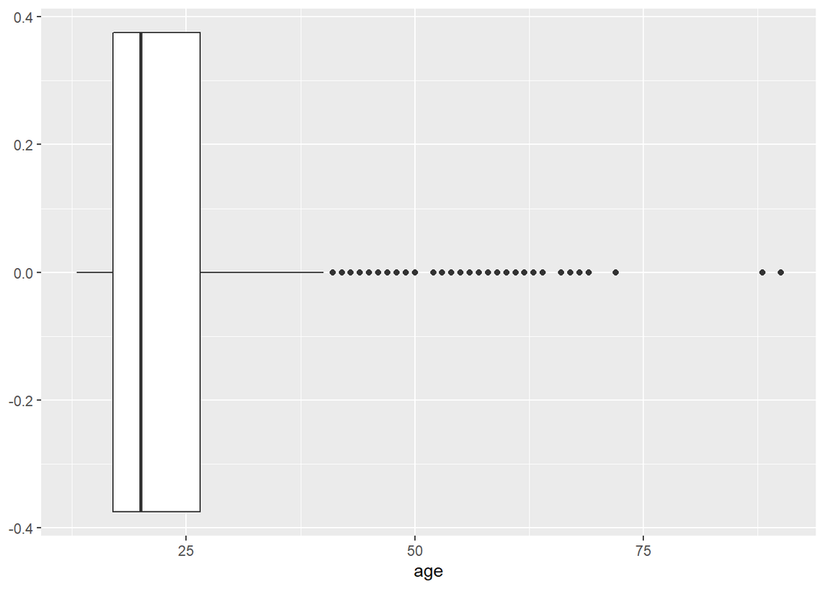

```r
nerd_red %>%
  ggplot(aes(x = age)) +
  geom_boxplot()
```

The plot will look much better with a different orientation, i.e. the data on the y-axis.

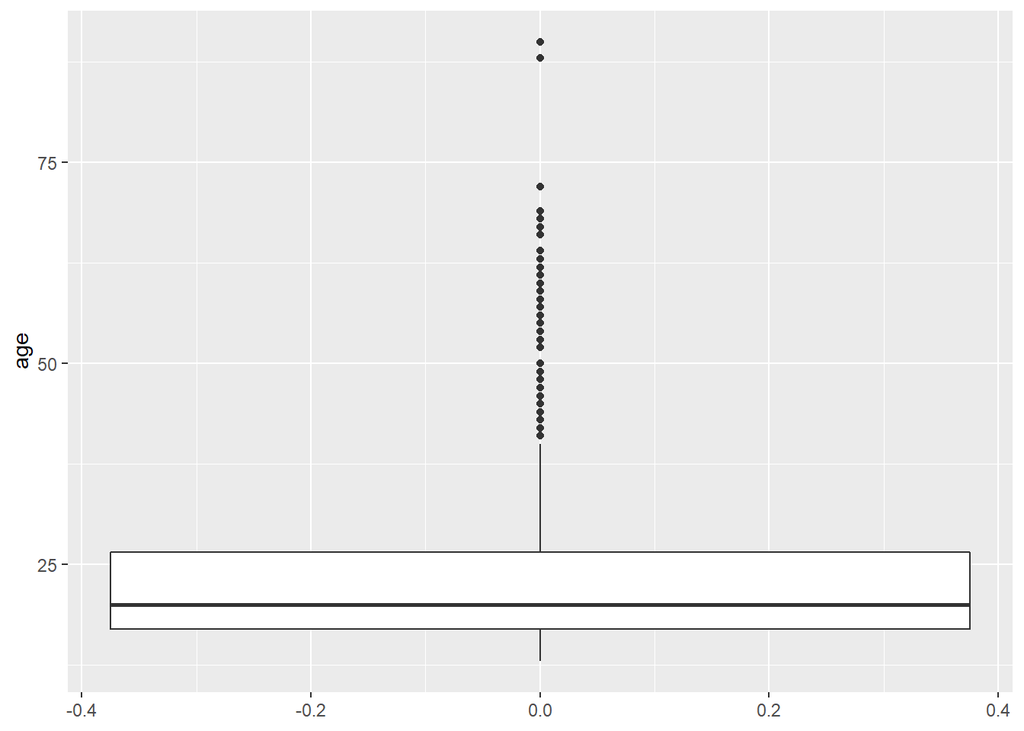

```r
nerd_red %>%
  ggplot(aes(y = age)) +
  geom_boxplot()
```

But still, the x-axis looks weird. Here’s how we can fix that: We’ll add a “dummy” for the x-axis so the ticks will be blank. There’s still that nasty little x as axis label - we’ll talk about how to get rid of that later.

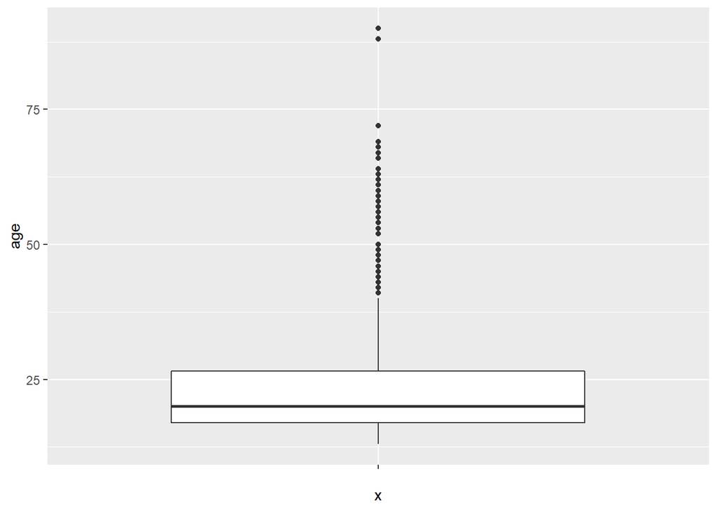

```r
nerd_red %>%
  ggplot(aes(y = age, x = "")) +
  geom_boxplot()
```

For now, let’s try another geom. How about a good old scatter plot? For this, we need some information on the x **and** y axis. What do we want to plot on next to age? Maybe the nerd score?

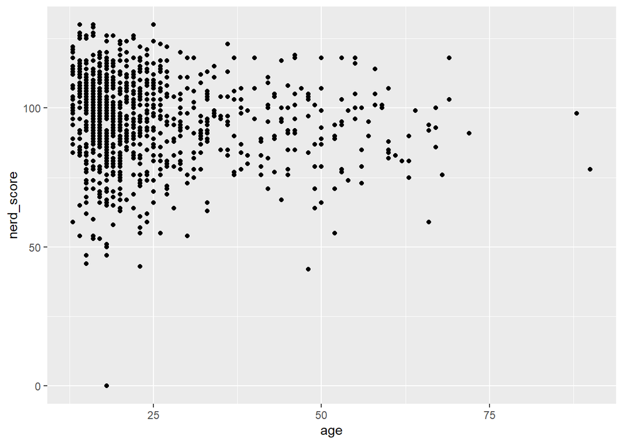

```r
nerd_red %>%
  ggplot(aes(x = age, y = nerd_score)) +
  geom_point()
```

When we think about scatter plots, we usually think about regression lines. How about adding a line to the data, indicating how age and nerd score are associated with each other? The corresponding geom is called `geom_smooth`.

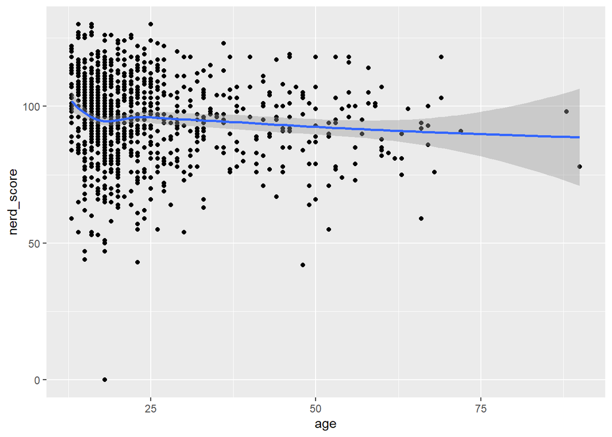

```r
nerd_red %>%
  ggplot(aes(x = age, y = nerd_score)) +
  geom_point() +
  geom_smooth()
```

The default method for `geom_smooth`, as `R` informs us, is “loess”. It “[fits] a polynomial surface determined by one or more numerical predictors, using local fitting.” (Run`?loess` in the console for more information.) You see that it does not produce a straight line - if we want a plain linear regression, we have to set the argument `method` to `"lm"`. With the argument `se = FALSE` we can get rid of the grey confidence interval around the data.

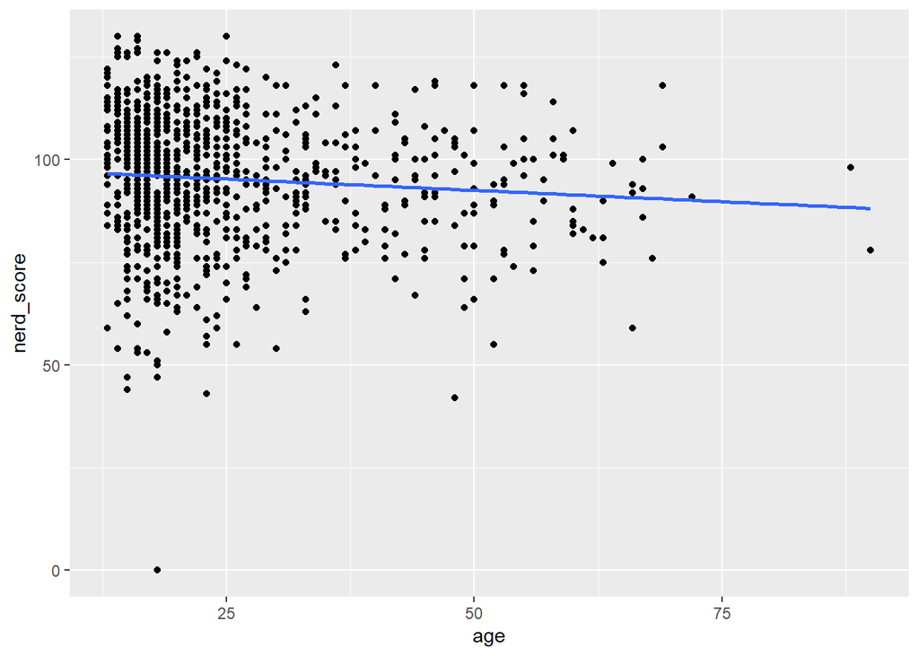

```r
nerd_red %>%
  ggplot(aes(x = age, y = nerd_score)) +
  geom_point() +
  geom_smooth(method = "lm", se = FALSE)
```

## Building plots

It is worth pointing out that you can a) save plots into variables just like anything else and b) that you can expand them bit by bit, i.e. you don’t have to copy-paste the whole code of the plot over and over again whenever you change something (like I do in this script).

Here, we save the scatter plot from before into a variable:

```r
my_scatter_plot <-
  nerd_red %>%
  ggplot(aes(x = age, y = nerd_score)) +
  geom_point()
```

… and call it here:

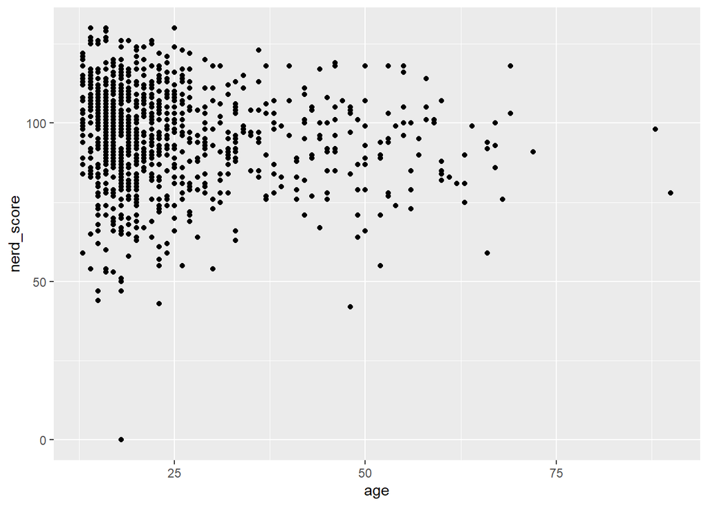

```r
my_scatter_plot
```

We can add the regression line to our existing plot like this:

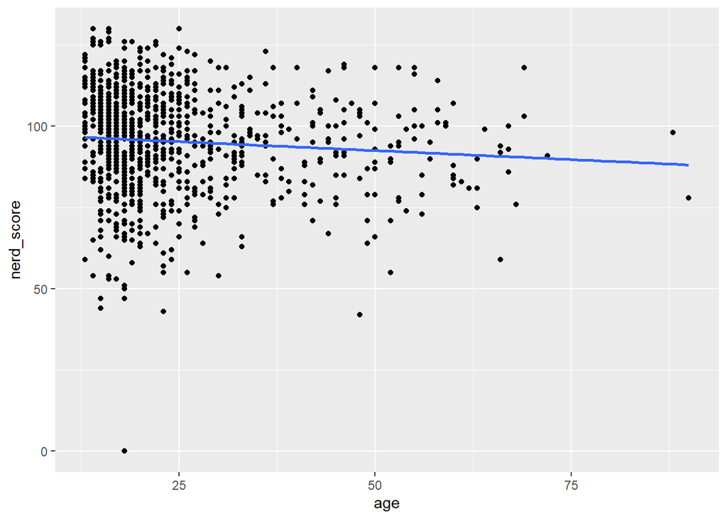

```r
my_scatter_plot +
  geom_smooth(method = "lm", se = FALSE)
```

Note that `my_scatter_plot` still contains only the scatter plot, without the regression line, because I did not overwrite it.

So while it would be entirely possible to modify only parts of the plot without having to recycle the code from before, I will always give you the whole code for each plot in this script. In my opinion, that makes it easier to understand how the plot was made, because nothing is hidden away in a variable. My usual workflow is to build my plots step by step, and I save them into variables once I’m done.

## Adding more complexity

Would you like to know how the relation between age and nerd score looks like for different subgroups of your data? We can easily split our plot by another variable, e.g. gender. Because gender is a property of our data, so it also goes into the `aes()` function.

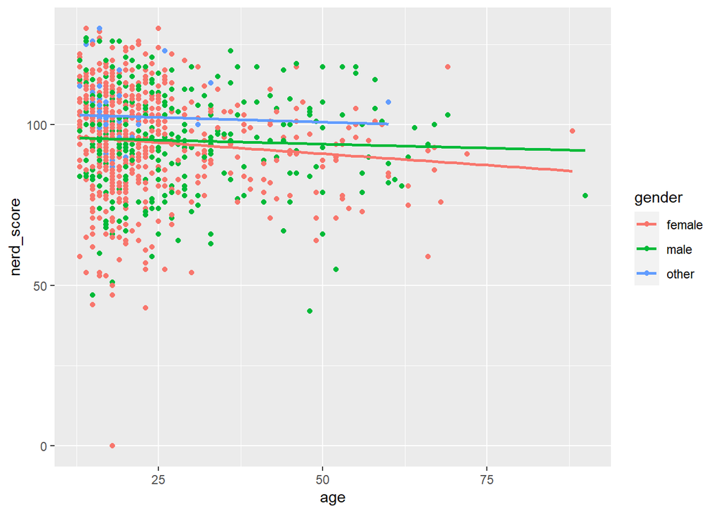

```r
nerd_red %>%
  ggplot(aes(x = age, y = nerd_score, colour = gender)) +
  geom_point() +
  geom_smooth(method = "lm", se = FALSE)
```

## Customise things

This is all fun and games, but let’s be honest, this plot is ugly. We want to customise it a little bit. For example, the text on the y axis says “nerd_score”, because `ggplot()` just put in the name of the column we told it to put on the y-axis. We can change that using `labs()`, which we can use to control the labels of our plot. (Try the arguments `x`, `title` or `subtitle`.)

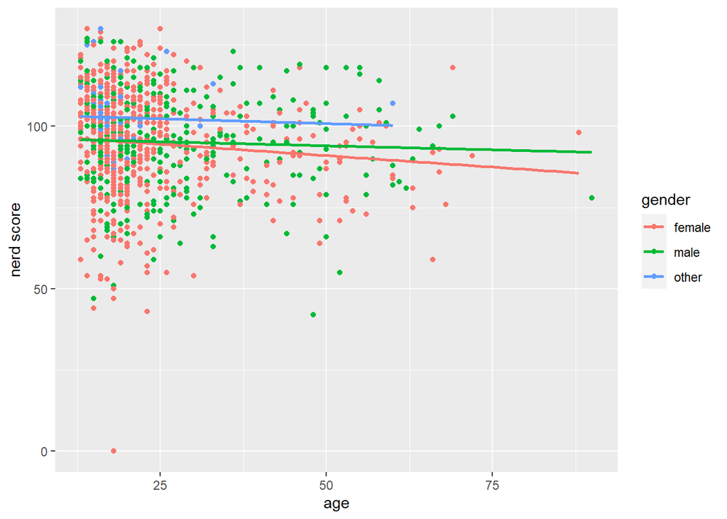

```r
nerd_red %>%
  ggplot(aes(x = age, y = nerd_score, colour = gender)) +
  geom_point() +
  geom_smooth(method = "lm", se = FALSE) +
  labs(y = "nerd score")
```

Next, let’s move the legend to the top of the plot. Using `theme()`, we can control **a lot** of things in our plot, like font sizes, whether there should be grid lines or not and much, much more.

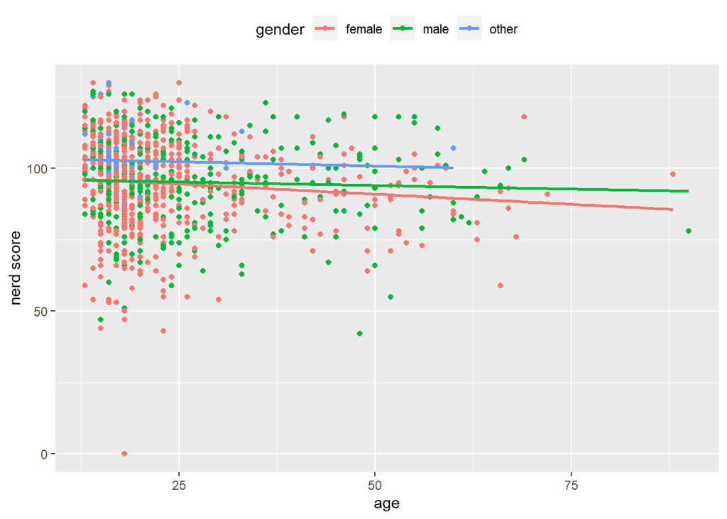

```r
nerd_red %>%
  ggplot(aes(x = age, y = nerd_score, colour = gender)) +
  geom_point() +
  geom_smooth(method = "lm", se = FALSE) +
  labs(y = "nerd score") +
  theme(legend.position = "top")
```

This grey plot grid is something `ggplot2` is very famous for. However, it might not be the most beautiful and modern plotting option. You can either set up a completely custom theme by manually customising all aspects of your plot using the `theme()` function, or you can use one of the many default themes, for example the classic theme. You can find a list of themes [here](https://ggplot2.tidyverse.org/reference/ggtheme.html).

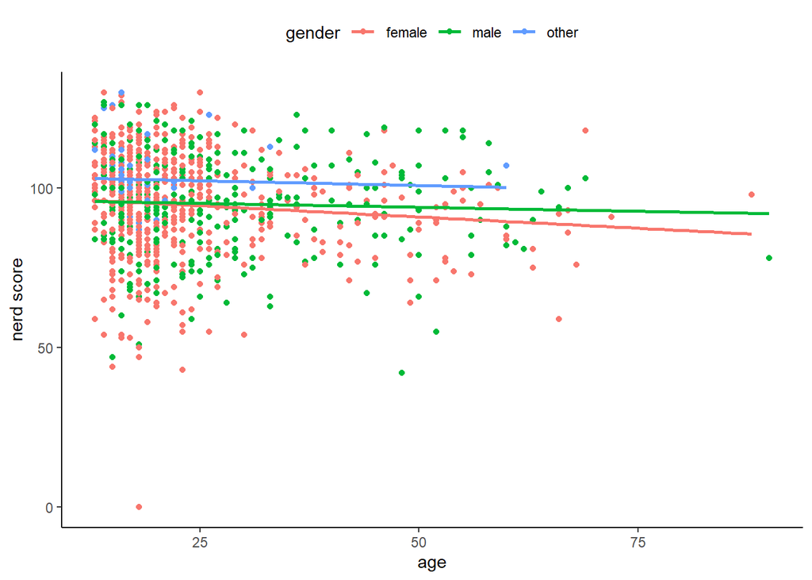

```r
nerd_red %>%
  ggplot(aes(x = age, y = nerd_score, colour = gender)) +
  geom_point() +
  geom_smooth(method = "lm", se = FALSE) +
  labs(y = "nerd score") +
  theme_classic() +
  theme(legend.position = "top")
```

Note that we have to put in `theme(legend.position = "top")` after `theme_classic()`, because in `theme_classic()`, the legend is on the right side of the plot. If we use `theme(legend.position = "top")` first, it gets overwritten by `theme_classic()`:

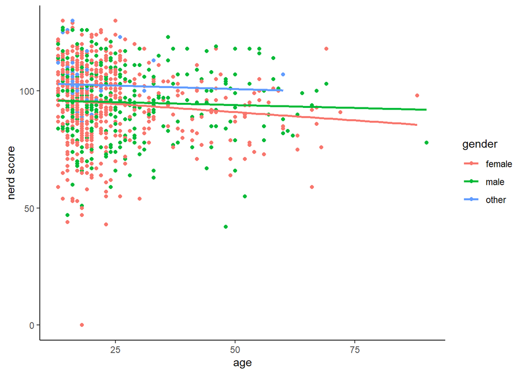

```r
nerd_red %>%
  ggplot(aes(x = age, y = nerd_score, colour = gender)) +
  geom_point() +
  geom_smooth(method = "lm", se = FALSE) +
  labs(y = "nerd score") +
  theme(legend.position = "top") +
  theme_classic()
```

## Axis steps

Our plot looks much better now. How about more fine-grained steps on the x and y axis? One quick way to set up the breaks on a plot axis is the function `seq()`. It generates a sequence of numbers. You give it the start point, the end point, and the stepsize:

```r
# A sequence from 1 - 10 in steps of 2
seq(1, 10, 2)
```

```
## [1] 1 3 5 7 9
```

It is also possible not to give a step size, but the **number** of steps (i.e. the length of the output) instead:

```r
seq(1, 10, length.out = 3)
```

```
## [1]  1.0  5.5 10.0
```

Now we can use `seq()` to adjust our axes like this:

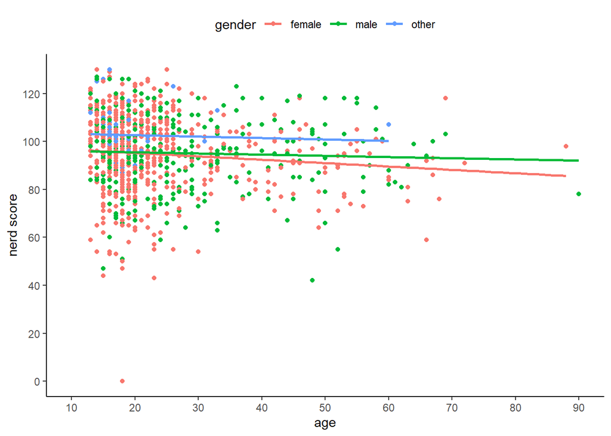

```r
nerd_red %>%
  ggplot(aes(x = age, y = nerd_score, colour = gender)) +
  geom_point() +
  geom_smooth(method = "lm", se = FALSE) +

  scale_x_continuous(breaks = seq(10, 90, 10), limits = c(10, 90)) +
  scale_y_continuous(breaks = seq(0, 130, 20)) +

  labs(y = "nerd score") +
  theme_classic() +
  theme(legend.position = "top")
```

# Geom appearance

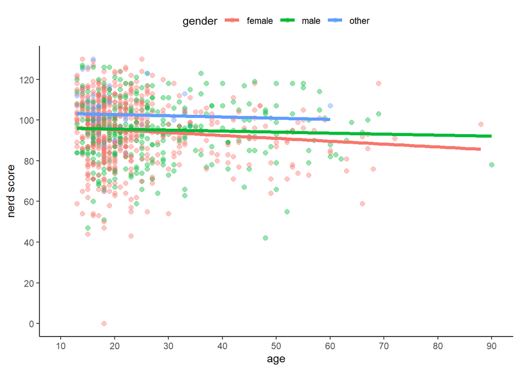

```r
# use alpha and size outside of the aes function!
nerd_red %>%
  ggplot(aes(x = age, y = nerd_score, colour = gender)) +
  geom_point(alpha = .4, size = 2) +
  geom_smooth(method = "lm", se = FALSE, size = 1.5) +

  scale_x_continuous(breaks = seq(10, 90, 10), limits = c(10, 90)) +
  scale_y_continuous(breaks = seq(0, 130, 20)) +

  labs(y = "nerd score") +
  theme_classic() +
  theme(legend.position = "top")
```

Let’s test our new skills and make our first histogram from before a little bit more beautiful. Here is what it looked like before:

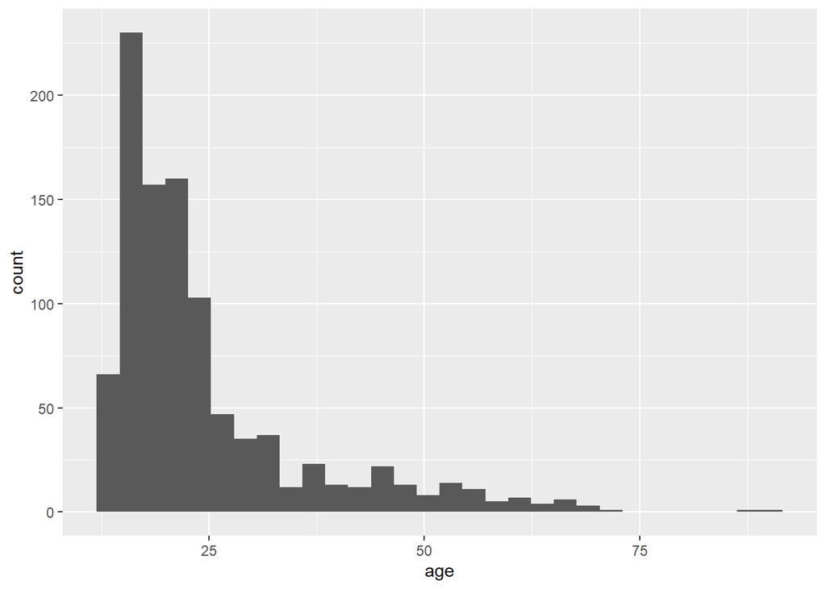

```r
nerd_red %>%
  ggplot(aes(x = age)) +
  geom_histogram()
```

Let’s change the theme and also add some colour. Note that some for some geoms or shapes, there is a distinction between `colour` and `fill`. Fill does exactly what the name suggests, and colour usually refers to the colour of the border. We can refer to the colour that we want by name (i.e. “black”, or “dark red” - find a full list [here](http://www.stat.columbia.edu/~tzheng/files/Rcolor.pdf)), but can also use hex codes.

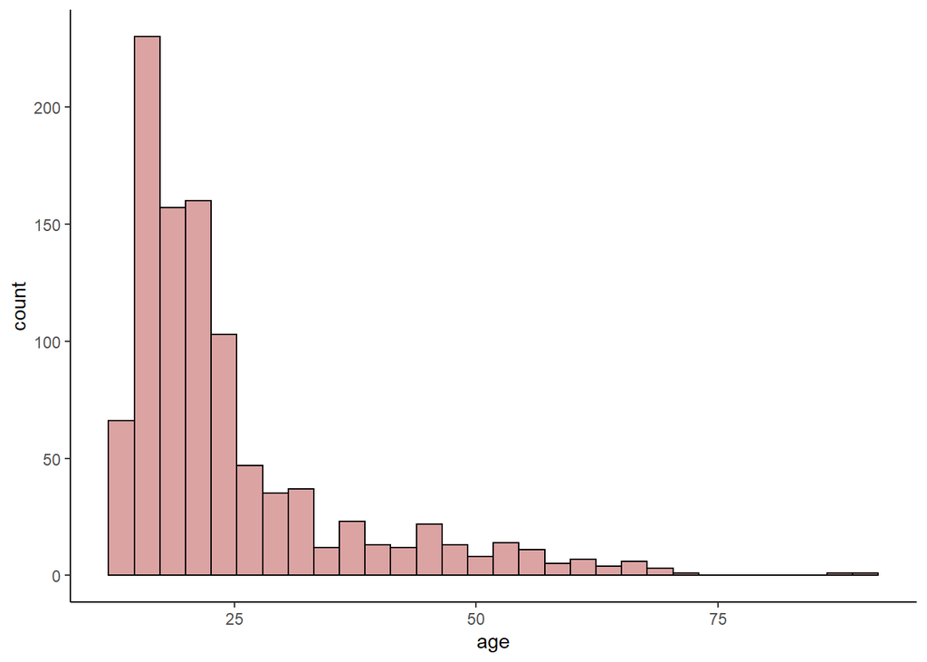

```r
nerd_red %>%
  ggplot(aes(x = age)) +
  geom_histogram(fill = "#dca3a3", colour = "black") +
  theme_classic()
```

1.1) Try to switch around `fill` and `colour` in the plot above, so that the colour is `"#dca3a3"` and the fill is `"black"`. What happens?

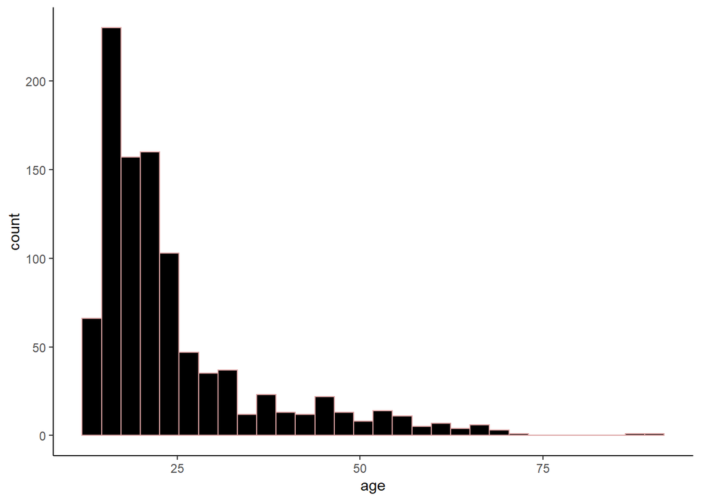

```r
nerd_red %>%
  ggplot(aes(x = age)) +
  geom_histogram(colour = "#dca3a3", fill = "black") +
  theme_classic()
```

You might be a bit confused now, because for our previous scatter plot, we used colour to change the colour of the circles, not of the **border** of the circles. That is because the circles we used before don’t have a border - or rather, they only consist of a border. There are several different shapes that we can use in our scatter plot, and we address them by different numbers using the `shape` argument. [Here](http://www.sthda.com/english/wiki/ggplot2-point-shapes) is a list of all available shapes. Shapes 21 - 25 respond to `colour` **and** `fill`.

Compare these two plots. The first one uses shape 20, the other shape 21. For the first plot, all the points are black, meaning they responded to the `colour` argument in our plot. However, `fill = "red"` does nothing.

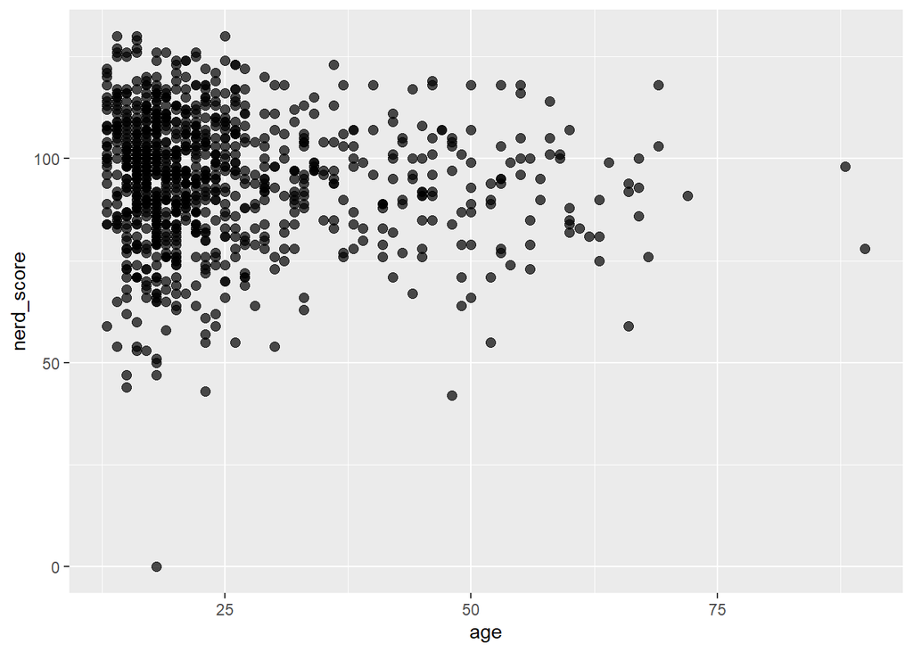

```r
nerd_red %>%
  ggplot(aes(x = age, y = nerd_score)) +
  geom_point(alpha = .7, size = 3.5, shape = 20, fill = "red", colour = "black")
```

In the second plot, shape number 21 responds to both `fill` and `colour`, with `fill` determining the colour of the inside of the circles, and `colour` determining the colour of the border.

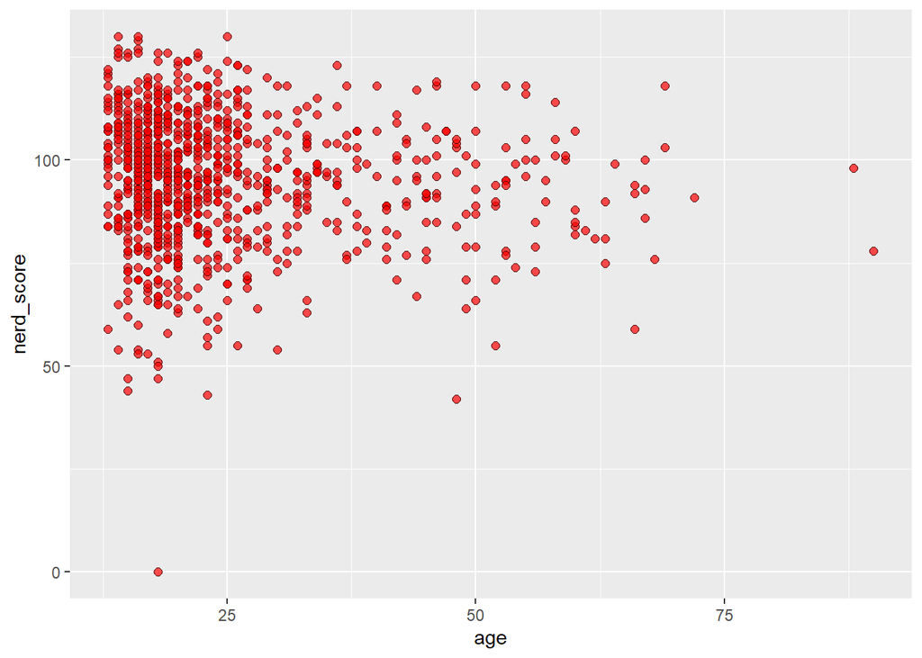

```r
nerd_red %>%
  ggplot(aes(x = age, y = nerd_score)) +
  geom_point(alpha = .7, size = 2, shape = 21, fill = "red", colour = "black")
```

Here is the same scatter plot as above, but using shape number 25 with the colour black. Note that we now use `fill = gender` instead of `colour = gender`!

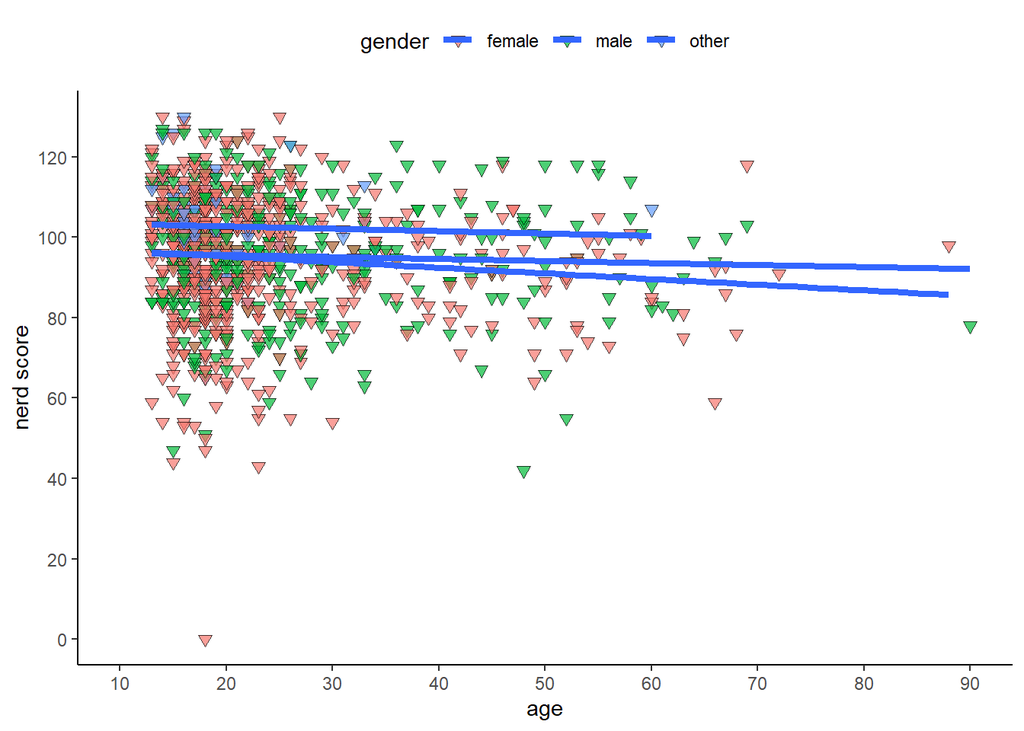

```r
# Shape doesn't have anything to do with our data, so it goes outside of
# the aes function!
# (I also increased alpha a bit)
nerd_red %>%
  ggplot(aes(x = age, y = nerd_score, fill = gender)) +
  geom_point(alpha = .7, size = 2, shape = 25, colour = "black") +
  geom_smooth(method = "lm", se = FALSE, size = 1.5) +

  scale_x_continuous(breaks = seq(10, 90, 10), limits = c(10, 90)) +
  scale_y_continuous(breaks = seq(0, 130, 20)) +

  labs(y = "nerd score") +
  theme_classic() +
  theme(legend.position = "top")
```

Woops. Because we changed `colour = gender` to `fill = gender`, the regression lines are not coloured anymore. We add `colour = gender` back to our `ggplot()` function. The interesting thing is that the colour of the triangles (i.e. the colour of their border) is not affected by this. `colour = "black"` comes after the `ggplot()` function, so `colour = gender` is overwritten for `geom_point()`. You can try to leave out `colour = "black"` and observe what happens.

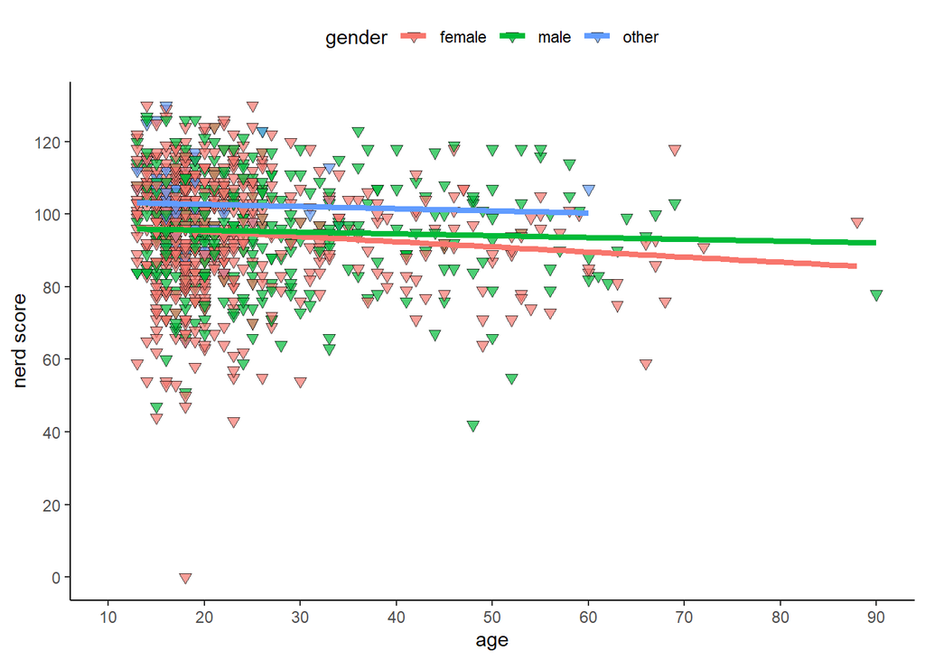

```r
nerd_red %>%
  ggplot(aes(x = age, y = nerd_score, fill = gender, colour = gender)) +
  geom_point(alpha = .7, size = 2, shape = 25, colour = "black") +
  geom_smooth(method = "lm", se = FALSE, size = 1.5) +

  scale_x_continuous(breaks = seq(10, 90, 10), limits = c(10, 90)) +
  scale_y_continuous(breaks = seq(0, 130, 20)) +

  labs(y = "nerd score") +
  theme_classic() +
  theme(legend.position = "top")
```

## Elements of the theme

We can control basically everything in our plot by interacting with its `theme`. To illustrate that, let’s do a box plot again, but this time, grouped by gender. Here, I use gender on both the x-axis **and** for the colour.

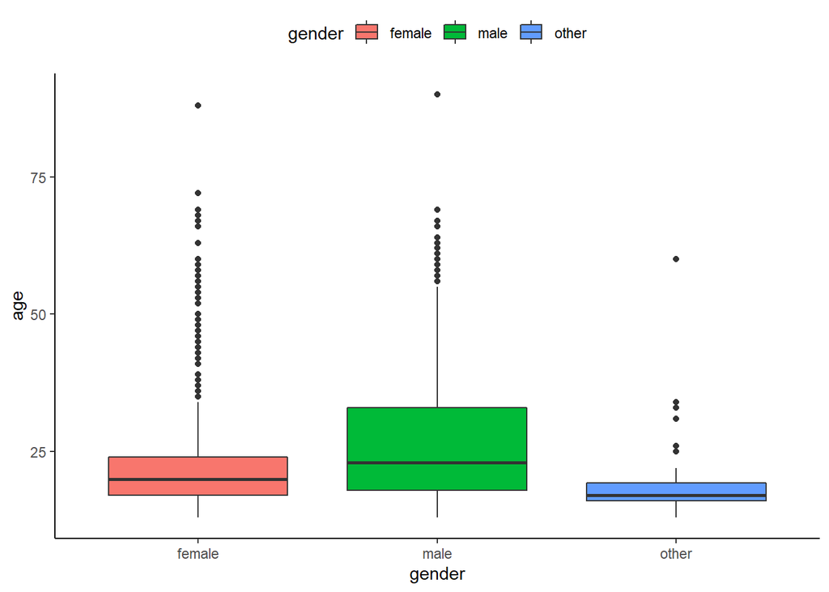

```r
nerd_red %>%
  ggplot(aes(x = gender, y = age, fill = gender)) +
  geom_boxplot() +
  theme_classic() +
  theme(legend.position = "top")
```

Having gender coded by both the colour **and** the x-axis is a bit redundant. We can use the `theme()` function to hide the x-axis. To do that, we have to keep in mind that the x-axis as a whole consists of several elements: The axis title (“gender”), the axis text (“female”, “male”, “other”) and the axis ticks. The axis line is also part of the axis, but this is something we want to keep. We can hide the different parts of the x-axis by telling `ggplot()` that they are an `element_blank()` - we turn them into “blank elements”.

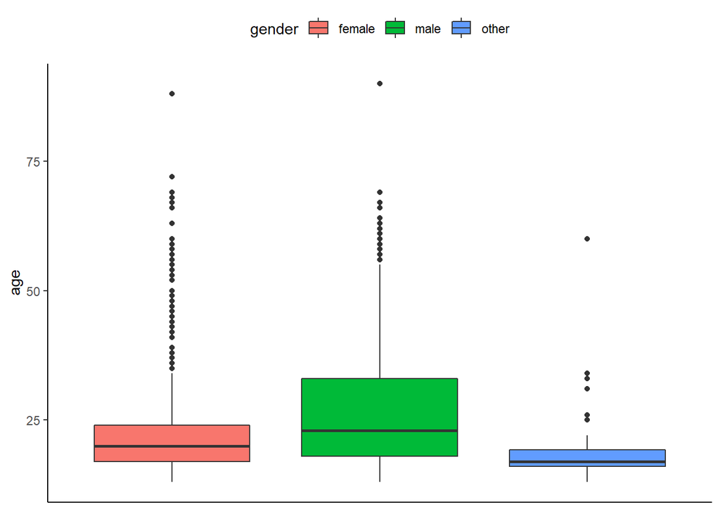

```r
nerd_red %>%
  ggplot(aes(x = gender, y = age, fill = gender)) +
  geom_boxplot() +
  theme_classic() +
  theme(
    legend.position = "top",
    axis.title.x = element_blank(),
    axis.text.x = element_blank(),
    axis.ticks.x = element_blank()
  )
```

We used `element_blank()` to hide the axis text, but we can also control it in different ways. Normally, the axis text is an `element_text()`, which responds to commands like `size` and `colour`, as it does in your favourite text editor. We can change the appearance of the axis text like this:

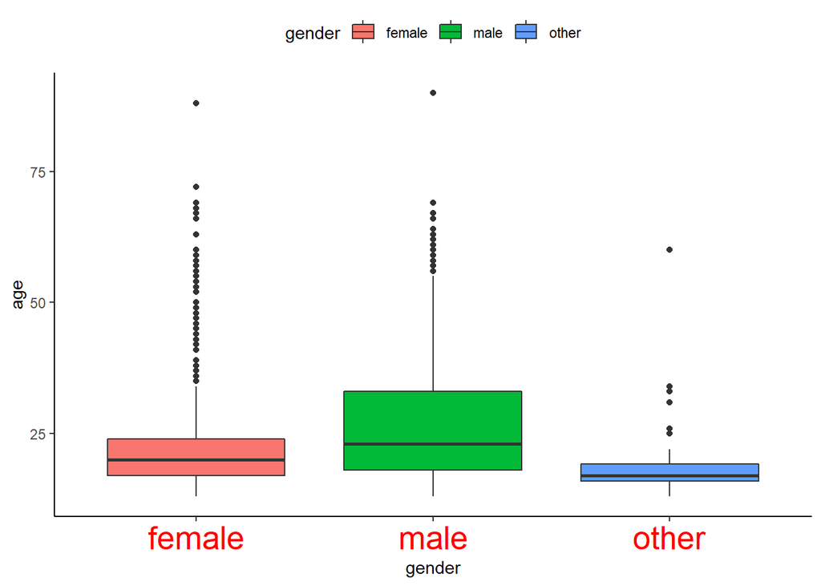

```r
nerd_red %>%
  ggplot(aes(x = gender, y = age, fill = gender)) +
  geom_boxplot() +
  theme_classic() +
  theme(
    legend.position = "top",
    axis.text.x = element_text(size = 20, colour = "red")
  )
```

You can toy around with different components of the plot theme. Just run `?theme` in the console and take a look at all the elements of your plot that you can potentially control. Try them out to find out what they are doing. It’s also worth to google a bit if there is something particular that you want to change in your plot. 99% of the time, someone on the internet had the same question and someone posted an answer to it.

2.1) In the boxplot above, add a title (hint: use `labs(title = "...")`). Use `?theme` in the console (or Google!) to find out how to change the title’s colour and its size. Bonus: Can you center the title?

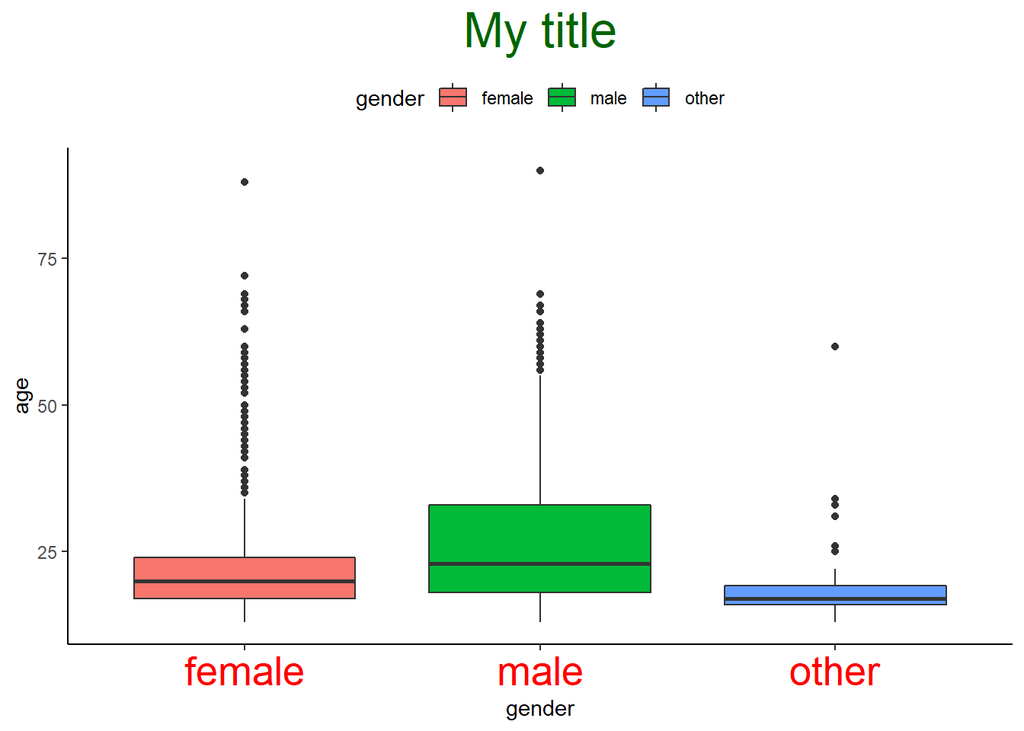

```r
nerd_red %>%
  ggplot(aes(x = gender, y = age, fill = gender)) +
  geom_boxplot() +
  theme_classic() +
  labs(title = "My title") + # use labs to add a title
  theme(
    legend.position = "top",
    axis.text.x = element_text(size = 20, colour = "red"),
    # Use plot.title and element_text() to change the appearance of the title
    # hjust = .5 (horizontal adjustment!) will center the title!
    plot.title = element_text(size = 24, colour = "dark green", hjust = .5)
  )
```

## More grouping

In a lot of cases, you want your plot to be grouped by several variables. For example, we could do a boxplot of the nerd score as a function of gender and whether people voted or not. On the x-axis, we have gender, but for each category on the x-axis, there are two boxplots - one for people who voted in blue, and one for people who did not vote in red.

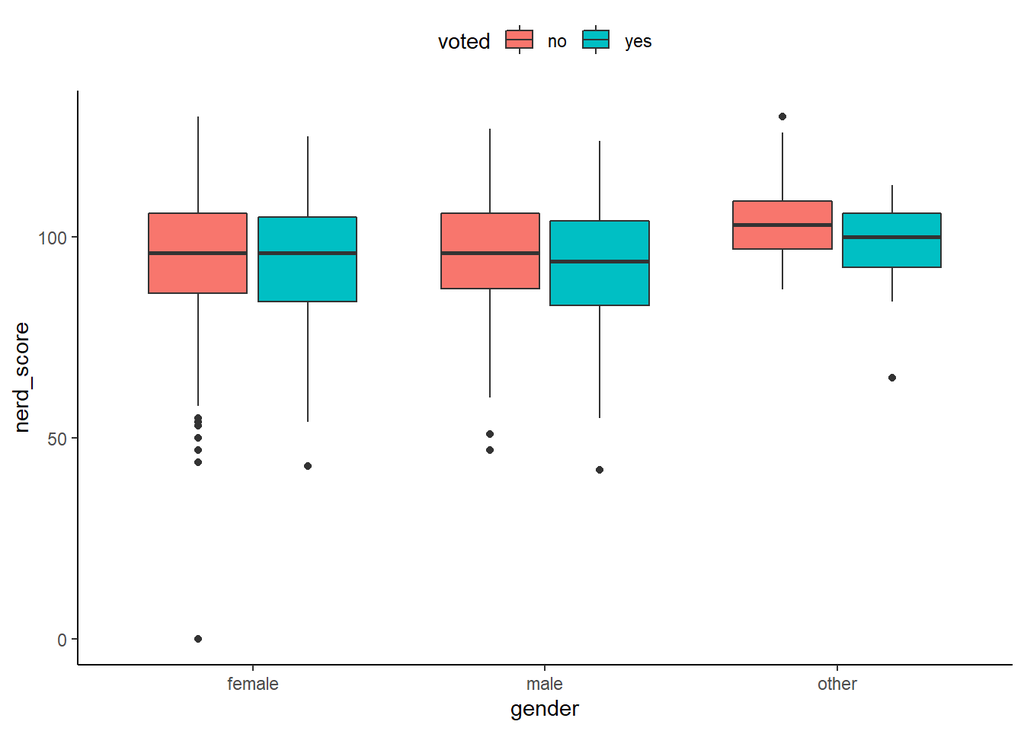

```r
nerd_red %>%
  ggplot(aes(x = gender, y = nerd_score, fill = voted)) +
  geom_boxplot() +
  theme_classic() +
  theme(legend.position = "top")
```

3.1) Change the y-axis title to “nerd score” (without the underscore) and increase the font size for: a) the legend title, b) the legend text, c) the axis title, d) the axis text.

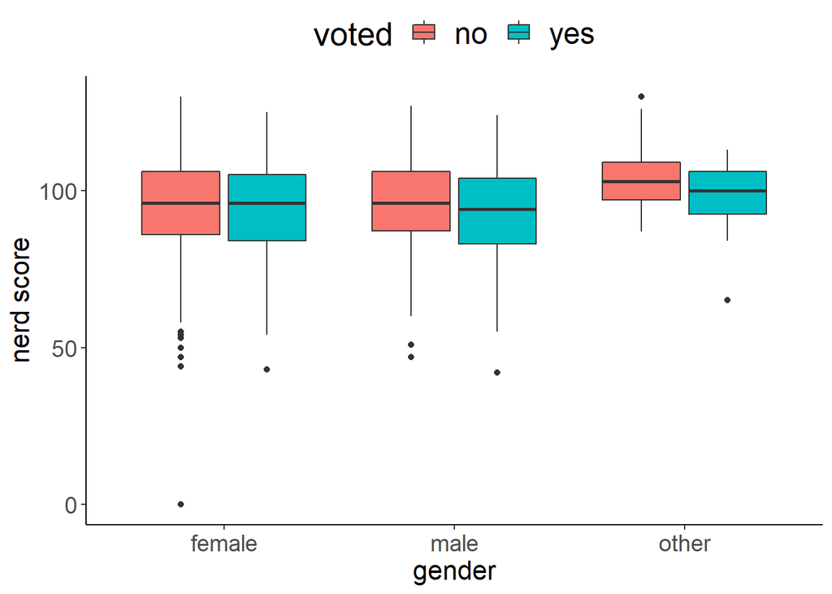

```r
nerd_red %>%
  ggplot(aes(x = gender, y = nerd_score, fill = voted)) +
  geom_boxplot() +
  labs(y = "nerd score") +
  theme_classic() +
  theme(
    legend.position = "top",
    legend.title = element_text(size = 20),
    legend.text = element_text(size = 18),
    axis.title = element_text(size = 16),
    axis.text = element_text(size = 14)
    )
```

We can also customise the colour (or rather: the fill!) of our boxplots by using the function `scale_fill_manual()`. In the first argument, I pick the legend’s name (observe the legend on top of the plot!), and with the argument `values`, I specify the colours I want to use. Because there are two colours in the plot, I need to provide two colours - the plot won’t work with less.

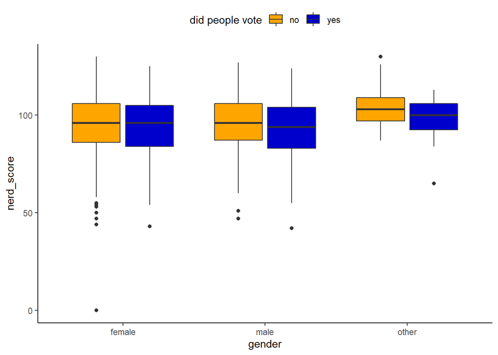

```r
nerd_red %>%
  ggplot(aes(x = gender, y = nerd_score, fill = voted)) +
  geom_boxplot() +
  scale_fill_manual("did people vote", values = c("orange", "blue3")) +
  theme_classic() +
  theme(legend.position = "top")
```

3.2) Create a scatter plot with age on the x-axis and the nerd score on the y-axis. Colour the points by whether people are married or not and let the size of the points vary as a function of self-reported nerdiness (column `nerdy`). (Note that both of these aesthetics - the colour and the size - depend on what’s in your data, so put them inside of the `aes()` function!) It’s easier to see what’s happening when there are not that many data points, so here is a tiny portion of `nerd_red`, only containing the first 100 participants (i.e. the first 100 rows). Use it to create your plot.

```r
nerd_tiny <- nerd_red[1:100, ]
```

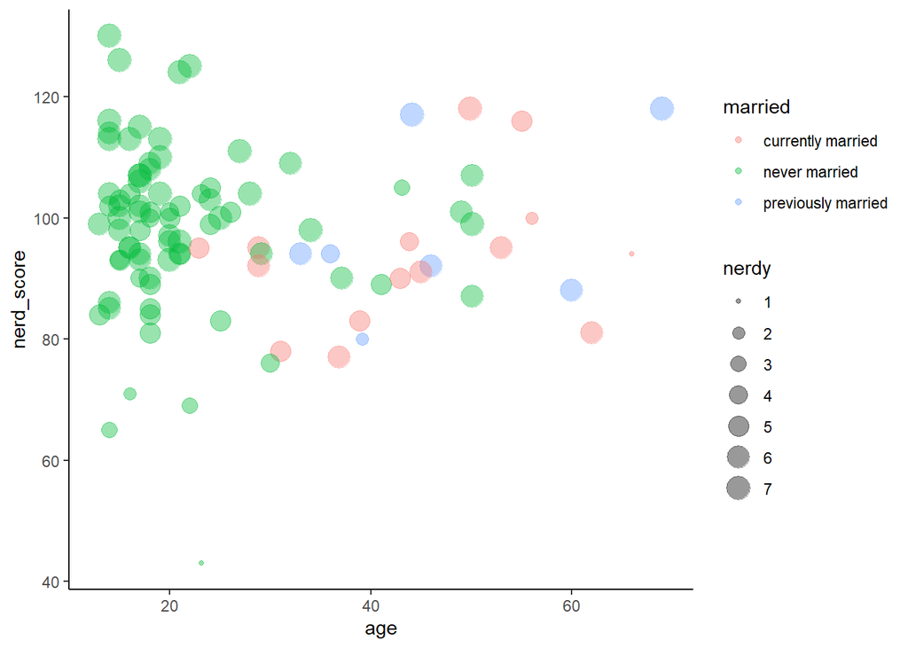

```r
nerd_tiny %>%
  ggplot(aes(x = age, y = nerd_score, colour = married, size = nerdy)) +
  geom_point(position = position_dodge(width = .5), alpha = .4) +
  theme_classic()
```

**THIS IS A GITHUB PUSH CHECKPOINT**